# Predicting Customer Purchasing Behavior and Lifetime Value

In this project, we will evaluate the predictive power of both the Pareto/NBD and modified BG/NBD models that has been trained and tested on customer data.

We will be using the [Lifetimes](https://github.com/CamDavidsonPilon/lifetimes) python library for our models and visualizations.

- [Official Documentation](https://lifetimes.readthedocs.io/en/latest/)

```python
import numpy as np
import pandas as pd
import matplotlib.pyplot as plt
```

```python
df = pd.read_csv("customer-data.csv")
```

## Data Exploration

```python
df.head()
```

|  | CustomerID | Timestamp | PurchaseValue |
| --- | --- | --- | --- |
| 0 | 5611860a94204a4078659f1667372cc4 | 2017-02-09T18:31:00Z | 4.72 |
| 1 | 07b260307114f9cffc5601eb7ad4b565 | 2017-06-28T19:26:00Z | 5.33 |
| 2 | 1ede55062d0d68c70fc4d355a5328d11 | 2017-07-28T17:47:00Z | 5.35 |
| 3 | 42b8e86e8da5e35628bcdc146c358665 | 2016-12-17T22:59:00Z | 6.00 |
| 4 | 1047f2787b7efc759d7ffcbc40ef7e19 | 2016-12-05T17:23:00Z | 6.28 |

### Reformatting Data

```python
df['Timestamp'] = pd.to_datetime(df['Timestamp'], format='%Y/%m/%d %H:%M').dt.date
```

```python
begin = df['Timestamp'].min()
end = df['Timestamp'].max()
print("The earliest date is {} | The latest date is {}".format(begin, end))
```

```
The earliest date is 2016-11-30 | The latest date is 2017-12-06
```

```python
from lifetimes.utils import summary_data_from_transaction_data

summary = summary_data_from_transaction_data(transactions=df,
                                             customer_id_col='CustomerID',
                                             datetime_col='Timestamp',
                                             monetary_value_col='PurchaseValue',
                                             observation_period_end='2017-12-06',
                                             freq='D').reset_index()
```

```python
summary.head()
```

|  | CustomerID | frequency | recency | T | monetary_value |
| --- | --- | --- | --- | --- | --- |
| 0 | 0001117ff1305c1fe840697166e61564 | 1.0 | 11.0 | 344.0 | 87.280 |
| 1 | 00028502859fd7e111d88c20456b59d5 | 0.0 | 0.0 | 342.0 | 0.000 |
| 2 | 000306d200fd6e9b03de48d15348f5c2 | 0.0 | 0.0 | 33.0 | 0.000 |
| 3 | 0003f3458a6e7b495a975c2d9ddda559 | 2.0 | 285.0 | 343.0 | 88.065 |
| 4 | 000784b838b807ad589d4bc69c0c562f | 0.0 | 0.0 | 210.0 | 0.000 |

```python
summary.info()
```

```
<class 'pandas.core.frame.DataFrame'>
RangeIndex: 23708 entries, 0 to 23707
Data columns (total 5 columns):
CustomerID        23708 non-null object
frequency         23708 non-null float64
recency           23708 non-null float64
T                 23708 non-null float64
monetary_value    23708 non-null float64
dtypes: float64(4), object(1)
memory usage: 926.2+ KB
```

```python
summary.describe()
```

|  | frequency | recency | T | monetary_value |
| --- | --- | --- | --- | --- |
| count | 23708.000000 | 23708.000000 | 23708.000000 | 23708.000000 |
| mean | 1.025477 | 58.355154 | 204.519403 | 94.028495 |
| std | 2.111326 | 98.565275 | 110.976868 | 168.026439 |
| min | 0.000000 | 0.000000 | 0.000000 | 0.000000 |
| 25% | 0.000000 | 0.000000 | 117.000000 | 0.000000 |
| 50% | 0.000000 | 0.000000 | 209.000000 | 0.000000 |
| 75% | 1.000000 | 86.000000 | 307.000000 | 146.722500 |
| max | 95.000000 | 371.000000 | 371.000000 | 3420.700000 |

### Data Calibration and Holdout

```python
from lifetimes.utils import calibration_and_holdout_data

summary_cal_holdout = calibration_and_holdout_data(transactions=df,
                                                   customer_id_col='CustomerID',
                                                   datetime_col='Timestamp',
                                                   calibration_period_end='2017-07-12', # 2/3rds between beginning and end dates
                                                   observation_period_end='2017-12-06',
                                                   freq='D',
                                                   monetary_value_col='PurchaseValue').reset_index()
```

```python
summary_cal_holdout.head()
```

|  | CustomerID | frequency_cal | recency_cal | T_cal | monetary_value_cal | frequency_holdout | monetary_value_holdout | duration_holdout |
| --- | --- | --- | --- | --- | --- | --- | --- | --- |
| 0 | 0001117ff1305c1fe840697166e61564 | 1.0 | 11.0 | 197.0 | 87.2800 | 0.0 | 0.00 | 147 |
| 1 | 00028502859fd7e111d88c20456b59d5 | 0.0 | 0.0 | 195.0 | 0.0000 | 0.0 | 0.00 | 147 |
| 2 | 0003f3458a6e7b495a975c2d9ddda559 | 1.0 | 2.0 | 196.0 | 76.6300 | 1.0 | 99.50 | 147 |
| 3 | 000784b838b807ad589d4bc69c0c562f | 0.0 | 0.0 | 63.0 | 0.0000 | 0.0 | 0.00 | 147 |
| 4 | 000ad0f90e9fcb6ff5a0bc480cccbdb3 | 4.0 | 52.0 | 53.0 | 87.6675 | 1.0 | 798.24 | 147 |

## Pareto/NBD model

Assumptions of Pareto/NBD:

- The number of transactiuons made by a customer follow a Poission process. Time between transactions follow an exponential distribution with transaction rate $\lambda$.
- Transaction rate $\lambda$ follows a gamma distribution.
- Customers have an unobserved "lifetime" of length $\tau$. Customer inactivity immediately after a transaction is distributed exponential with dropout rate $\mu$.
- Dropout rate $\mu$ follows a gamma distribution with parameters $s$ and $\beta$.
- Transaction rate and dropout probability vary independently across customers.

Part one of the first assumption is the number of transactions a customer makes follows a Poission process. This is where individual transactions are independent from each other, the transaction rate is constant and two transactions cannot occur simultaneously. The second part describes the time between transaction to be exponential where customers make many short repeat purchases rather than few longer repeat purchases. The second assumption describes the transaction rate as a gamma distribution. The third assumption assumes customers are immediately inactive after a transaction. The probability of customer inactivity follows an exponential distribution, this is also known as the standard exponential survival function. This function requires a parameter $\mu$ that follows a gamma distribution. While the last assumption is independence between transaction rate $\lambda$ and dropout probability p for each customer.

## Implement the Pareto/NBD model

```python
from lifetimes import ParetoNBDFitter

pareto = ParetoNBDFitter(penalizer_coef=0.0)
pareto.fit(frequency=summary_cal_holdout['frequency_cal'],
           recency=summary_cal_holdout['recency_cal'],
           T=summary_cal_holdout['T_cal'])
```

```
<lifetimes.ParetoNBDFitter: fitted with 16182 subjects, alpha: 115.21, beta: 10.44, r: 1.02, s: 0.21>
```

```python
pareto.params_
```

```
r          1.015726
alpha    115.209147
s          0.213569
beta      10.437975
dtype: float64
```

## Modified BG/NBD model

Assumptions of modified BG/NBD:

- The number of transactions made by a customer follow a Poission process. Time between transactions follow a exponential distribution with transaction rate $\lambda$.
- Transaction rate $\lambda$ follows a gamma distribution.
- Immediately after a transaction, a customer is inactive with probability p. Customer dropout is distributed across transactions according to a shifted geometric distribution.
- Customer inactivity probability p follows a beta distribution.
- Transaction rate and dropout probability vary independently across customers.

The first two assumptions of BG/NBD model are identical to the Pareto/NBD model. The third assumption differs from the Pareto/NBD assumption of customer inactivity. Customer inactivity is determined immediately after a transaction as a probability p. With each additional transaction, a customer has a lower probability of becoming inactive. While few transactions increases the probability of customer inactivity. The fouth assumption being that p follows a beta distribution with $\alpha$ and $\beta$ as pdf parameters. While the last assumption is independence between transaction rate $\lambda$ and dropout probability p for each customer.

## Implement the modified BG/NBD model

```python
from lifetimes import ModifiedBetaGeoFitter
from lifetimes.plotting import plot_calibration_purchases_vs_holdout_purchases
from lifetimes.plotting import plot_period_transactions

mbg = ModifiedBetaGeoFitter(penalizer_coef=0.0)
mbg.fit(frequency=summary_cal_holdout['frequency_cal'],
        recency=summary_cal_holdout['recency_cal'],
        T=summary_cal_holdout['T_cal'])
```

```
<lifetimes.ModifiedBetaGeoFitter: fitted with 16182 subjects, a: 0.77, alpha: 72.39, b: 1.57, r: 0.87>
```

```python
mbg.summary
```

|  | coef | se(coef) | lower 95% bound | upper 95% bound |
| --- | --- | --- | --- | --- |
| r | 0.869037 | 0.075572 | 0.720917 | 1.017158 |
| alpha | 72.385291 | 4.552203 | 63.462974 | 81.307608 |
| a | 0.767569 | 0.080816 | 0.609170 | 0.925968 |
| b | 1.571636 | 0.284603 | 1.013814 | 2.129457 |

## Model Comparison

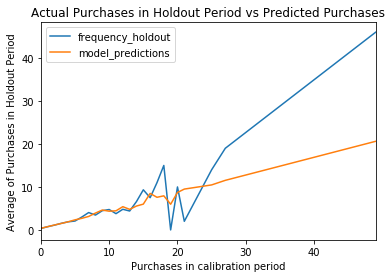

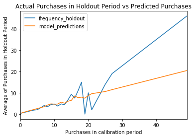

```python
plot_calibration_purchases_vs_holdout_purchases(mbg, summary_cal_holdout, n=50)
plot_calibration_purchases_vs_holdout_purchases(pareto, summary_cal_holdout, n=50)
```

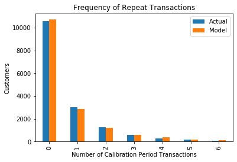

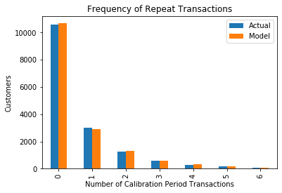

```python
plot_period_transactions(pareto)
plot_period_transactions(mbg)
```

### 10 customers predicted to make the most purchases over the next 12 months.

```python
summary['pred_purchases_pareto'] = pareto.conditional_expected_number_of_purchases_up_to_time(t=365,
                                                                                              frequency=summary['frequency'],
                                                                                              recency=summary['recency'],
                                                                                              T=summary['T'])
```

```python
summary['pred_purchases_mbg'] = mbg.conditional_expected_number_of_purchases_up_to_time(t=365,
                                                                                        frequency=summary['frequency'],
                                                                                        recency=summary['recency'],
                                                                                        T=summary['T'])
```

```python
summary[['CustomerID', 'pred_purchases_pareto']].sort_values(by='pred_purchases_pareto', ascending=False).head(10)
```

|  | CustomerID | pred_purchases_pareto |
| --- | --- | --- |
| 15336 | a5fadc51b1ae844ad9a70ad3cfa46a64 | 66.616811 |
| 6716 | 48a503edbaded96a3be27deee11967a1 | 32.397267 |
| 14705 | 9f447f9415a380ac2eeee7df49c6ee7e | 27.002827 |
| 8831 | 5f01420f0edda6555df5ce1cc62b986c | 26.997385 |
| 13047 | 8d2ce54737dd404d20cadf1405d46dc8 | 23.979793 |
| 5479 | 3b11478939967e896ae2619615650f97 | 21.768366 |
| 15357 | a62a17bb46864da2c6da691d838971b3 | 21.724654 |
| 3941 | 2ad9a83ee23110d8c2f4c01600b94f20 | 20.998205 |
| 10926 | 75fda9ea22086bf3814ff8c3f53de8ca | 20.652870 |
| 8399 | 5ac5ed64cd99ed2a8403b7a927e644ef | 20.089397 |

```python
summary[['CustomerID', 'pred_purchases_mbg']].sort_values(by='pred_purchases_mbg', ascending=False).head(10)
```

|  | CustomerID | pred_purchases_mbg |
| --- | --- | --- |
| 15336 | a5fadc51b1ae844ad9a70ad3cfa46a64 | 61.483878 |
| 6716 | 48a503edbaded96a3be27deee11967a1 | 29.277651 |
| 14705 | 9f447f9415a380ac2eeee7df49c6ee7e | 24.116376 |
| 8831 | 5f01420f0edda6555df5ce1cc62b986c | 23.150874 |
| 13047 | 8d2ce54737dd404d20cadf1405d46dc8 | 21.807302 |
| 15357 | a62a17bb46864da2c6da691d838971b3 | 19.775169 |
| 5479 | 3b11478939967e896ae2619615650f97 | 19.339583 |
| 3941 | 2ad9a83ee23110d8c2f4c01600b94f20 | 18.908355 |
| 10926 | 75fda9ea22086bf3814ff8c3f53de8ca | 18.571341 |
| 4470 | 30aa99d3357244cf38ca04eadef1473a | 17.564054 |

## Implement the Gamma-Gamma CLV model

```python
returning_customers_summary = summary[summary['frequency']>0]
```

### Confirm Gamma-Gamma submodel assumption of independence between monetary value and purchase frequency.

```python
returning_customers_summary[['monetary_value', 'frequency']].corr()
```

|  | monetary_value | frequency |
| --- | --- | --- |
| monetary_value | 1.000000 | 0.042791 |
| frequency | 0.042791 | 1.000000 |

```python
from lifetimes import GammaGammaFitter

ggf = GammaGammaFitter(penalizer_coef=0.0)
ggf.fit(frequency=returning_customers_summary['frequency'],
        monetary_value=returning_customers_summary['monetary_value'])
```

```
<lifetimes.GammaGammaFitter: fitted with 9647 subjects, p: 4.57, q: 3.65, v: 135.88>
```

```python
summary['pred_clv_pareto'] = ggf.customer_lifetime_value(transaction_prediction_model=pareto,
                                                         frequency=summary['frequency'],
                                                         recency=summary['recency'],
                                                         T=summary['T'],
                                                         monetary_value=summary['monetary_value'],
                                                         time=12,
                                                         freq="D")
```

```python
summary['pred_clv_mbg'] = ggf.customer_lifetime_value(transaction_prediction_model=mbg,
                                                  frequency=summary['frequency'],
                                                  recency=summary['recency'],
                                                  T=summary['T'],
                                                  monetary_value=summary['monetary_value'],
                                                  time=12,
                                                  freq="D")
```

```python
summary[['CustomerID', 'pred_clv_pareto']].sort_values(by='pred_clv_pareto', ascending=False).head(10)
```

|  | CustomerID | pred_clv_pareto |
| --- | --- | --- |
| 15336 | a5fadc51b1ae844ad9a70ad3cfa46a64 | 26728.469522 |
| 18747 | ca2202a96c2de6ca6b8a37a4a73fa730 | 16767.648508 |
| 20502 | dca76db00cc59dfbcdcc97c8bbc7f9f1 | 12006.807732 |
| 8399 | 5ac5ed64cd99ed2a8403b7a927e644ef | 11513.775184 |
| 9000 | 60c19a709e3ced2d16d7100eb1069df5 | 9788.983059 |
| 840 | 089ecc49200cfe79584d0bec2a3cf8c0 | 8031.240966 |
| 14142 | 98f8e41f45721cbe49a3147f6cf62432 | 7523.141337 |
| 8831 | 5f01420f0edda6555df5ce1cc62b986c | 7463.519669 |
| 6061 | 42059a7ede026d409ff0f255635d7a08 | 7439.464856 |
| 21927 | eba458987dc67827871c1d4d92e646e1 | 7183.999161 |

```python
summary[['CustomerID', 'pred_clv_mbg']].sort_values(by='pred_clv_mbg', ascending=False).head(10)
```

|  | CustomerID | pred_clv_mbg |
| --- | --- | --- |
| 15336 | a5fadc51b1ae844ad9a70ad3cfa46a64 | 24788.383849 |
| 18747 | ca2202a96c2de6ca6b8a37a4a73fa730 | 16919.328064 |
| 20502 | dca76db00cc59dfbcdcc97c8bbc7f9f1 | 10323.236506 |
| 8399 | 5ac5ed64cd99ed2a8403b7a927e644ef | 9066.358529 |
| 9000 | 60c19a709e3ced2d16d7100eb1069df5 | 8534.193337 |
| 8831 | 5f01420f0edda6555df5ce1cc62b986c | 6430.500963 |
| 840 | 089ecc49200cfe79584d0bec2a3cf8c0 | 6331.232894 |
| 10770 | 742d5a52d4df7cb14246d7f390de5d8a | 6316.257136 |
| 21927 | eba458987dc67827871c1d4d92e646e1 | 6205.817645 |
| 15442 | a719d6643a7832535de9aded2f467825 | 6194.385123 |

## Model Analysis and Evaluation

The model does well when predicting customer purchasing behavior with smaller frequencies. From the figure below, the model does well at the beginning where frequencies are small. We then see the model generalize rather well while also responding to minor changes. These results are due to the majority of observations being smaller frequencies than larger frequencies. As there are fewer observations on the larger frequencies, the model struggles to predict customer purchasing behavior. As a result of the models inability to predict customer purchasing behavior of larger frequencies can also affect how CLV is predicted. With varying predictions for large frequencies, CLV predictions will be conservative.

An idea is to add/adjust model fit weights. In the documentation the weights parameter calculates the log-likelihood for given patterns in the data rather than individual calculations. This would compensate for the lack of observations as well as focus on particular patterns in the data. The model would be able to predict customer purchasing behavior, as well as better tune CLV predictions for those with higher frequencies.

Comparing the Pareto/NBD and Modififed BG/NBD models, the differences are rather small. The problem with the Pareto/NBD model is its computational demand. The model attempts multiple evaluations of the Gaussian hypergeometric function for an individual customer. As a result, numerical optimization becomes difficult when solving for the maximum likelihood function. The Modified BG/NBD model solves the issues that occur with the Pareto/NBD model. By having a single evaluation of the Gaussian hypergeometric function for an individual customer, computation is less burdensome.

## Model Simulation

### Simulation of customer alive after 10 days, 1 year, 10 years and 100 years

```python
from lifetimes.generate_data import modified_beta_geometric_nbd_model
from lifetimes.generate_data import pareto_nbd_model

times = [10, 365, 3650, 36500] # periods in terms of days
r_par, alpha_par, s, beta = pareto.params_
r_mbg, alpha_mbg, a, b = mbg.summary['coef']
size = 100

for duration in times:

    generated_customers_par = pareto_nbd_model(T=duration,
                                               r=r_par,
                                               alpha=alpha_par,
                                               s=s,
                                               beta=beta,
                                               size=size)

    generated_customers_mbg = modified_beta_geometric_nbd_model(T=duration,
                                                                r=r_mbg,
                                                                alpha=alpha_mbg,
                                                                a=a,
                                                                b=b,
                                                                size=size)

    print("Duration: {}".format(duration))
    print("Pareto/NBD : Modified BG/NBD")
    print("Number of Purchases: {} : Number of Purchases: {}".format(generated_customers_par['frequency'].sum(),
                                                                           generated_customers_mbg['frequency'].sum()))

    print("Number of Customers Alive: {} : Number of Customers Alive: {}".format(generated_customers_par['alive'].sum(),
                                                                                 generated_customers_mbg['alive'].sum()))
    print("-----------------------------------------------------------------")
```

```
Duration: 10
Pareto/NBD : Modified BG/NBD
Number of Purchases: 9.0 : Number of Purchases: 11.0
Number of Customers Alive: 86.0 : Number of Customers Alive: 67.0
-----------------------------------------------------------------
Duration: 365
Pareto/NBD : Modified BG/NBD
Number of Purchases: 225.0 : Number of Purchases: 154.0
Number of Customers Alive: 44.0 : Number of Customers Alive: 38.0
-----------------------------------------------------------------
Duration: 3650
Pareto/NBD : Modified BG/NBD
Number of Purchases: 1452.0 : Number of Purchases: 600.0
Number of Customers Alive: 31.0 : Number of Customers Alive: 16.0
-----------------------------------------------------------------
Duration: 36500
Pareto/NBD : Modified BG/NBD
Number of Purchases: 5361.0 : Number of Purchases: 914.0
Number of Customers Alive: 15.0 : Number of Customers Alive: 3.0
-----------------------------------------------------------------
```